# Ridge Regression for Quantifying Coffee Adulteration: SNV+SG+2nd Derivative Spectra

Author

Derick Malavi

## Introduction

Coffee adulteration, such as blending premium Arabica with lower-cost Robusta, undermines quality and authenticity, posing significant challenges for consumers, producers, and regulators. High-dimensional spectroscopic data provides valuable insights for detecting such fraud. However, analyzing the full spectra presents challenges due to the large number of variables, necessitating robust methods to manage dimensionality and isolate relevant wavelengths effectively.

This study employs Ridge Regression as a prediction method to handle high-dimensional spectroscopic data. Ridge Regression applies L2 regularization, which shrinks coefficient magnitudes without eliminating any features. By effectively addressing multi-collinearity, Ridge Regression retains all spectral variables while reducing the impact of less informative wavelengths. This approach ensures robust predictions while maintaining the full spectral resolution.

```r
# Load libraries
warning = FALSE
  suppressWarnings(suppressMessages({
  library(caret)
  library(GA)
  library(glmnet)
  library(viridis)
  library(Boruta)
  library(ggplot2)
  library(dplyr)
  library(readxl)
  library(readr)
  library(janitor)
  library(class)
  library(MLmetrics)
  library(MLeval)
  library(themis)
  library(ROSE)
  library(parallel)
  library(doParallel)
  library(foreach)
  library(pheatmap)
  library(mdatools)
  library(nnet)
  library(DMwR)
  library(e1071)
  library(knitr)
  library(pROC)
  library(gridExtra)
  library(FactoMineR)
  library(doSNOW)
  library(MASS)
  library(factoextra)
  library(kernlab)}))
```

## Prepare Data

```r
# Load data: snv_sg_2d spectra

hsi_snv_sg_2d <- read.csv("coffee_instant_snv_sg_2d.csv")

# Ensure we have the same number of dimensions and the range of our columns/covariates
dim(hsi_snv_sg_2d)
```

```
[1] 1476  229
```

```r
# Check a few column names
col_check <- colnames(hsi_snv_sg_2d[,c(1:6)])
col_check
```

```
[1] "sample_name"  "binary_class" "three_class"  "cal_val"      "perc_adulter"
[6] "X935.609985"
```

```r
# our response variable (adulteration percentage) is column 4
# The spectral values start from column # 6 -------> 229

# Convert the adulteration percentage to numeric for compatibility with ML
hsi_snv_sg_2d$perc_adultert <- as.numeric(hsi_snv_sg_2d$perc_adulter)
```

## Get the X and y variables

```r
X <- hsi_snv_sg_2d[,c(6:229)]
y <- hsi_snv_sg_2d[,5]

class(y) #Ensure y (target variable) is a numeric for regression
```

```
[1] "integer"
```

## Split the Data (Train_Test Split)

- We want to select features based on training data only to avoid any data leakage that could inflate model performance and make the model less generalizable to unseen data.

```r
# Subset samples for cross-validation and external validation (70/30)
# Record 1 under cal_val variable is for calibration while 2 will be for testing the model

sample<-hsi_snv_sg_2d$cal_val == 1

# Split to train and test sets
X_train <- X[sample,]
X_test <- X[!sample,]
y_train <-y[sample]
y_test <- y[!sample]

# Check length of the subsets for training and validation
dim(X_train)
```

```
[1] 1065  224
```

```r
dim(X_test)
```

```
[1] 411 224
```

```r
length(y_train)
```

```
[1] 1065
```

```r
length(y_test)
```

```
[1] 411
```

```r
# Merge the test and train data
train_data <- data.frame(y_train, X_train)
test_data <- data.frame(y_test, X_test)
```

## Train Models

```r
# Set random seed for reproducibility
set.seed (123)

# Set up the training control(10 folds 10 times cross_validation)
control <- trainControl(method = "repeatedcv", number = 10, repeats = 10,
                        savePredictions = "final",
                        summaryFunction = defaultSummary,
                        selectionFunction = 'best', allowParallel = TRUE)

# We used oneSE for classification. For regression, we will use 'best': a model that minimizes RMSECV
```

```r
#Set the metric as accuracy
metric<-"RMSE"
```

```r
# Hyperparameter set
# alpha: Set to 0 for Ridge (pure L2 regularization).
# lambda: Regularization strength (penalty parameter). A sequence of values is tested to identify the best lambda.

grid <- expand.grid(alpha = 0, lambda = 10^seq(-3, 3, length = 100))
```

# Train Ridge

```r
set.seed(123)
#Register cluster for caret to train the models in parallel
cl<-makeCluster(6,type = "SOCK")
suppressWarnings(suppressMessages(
  registerDoSNOW(cl)))

# Start_time
start_time<-Sys.time()

#Train the model using cross-validation (10 folds, 10 times)
fit_ridge_snv_sg_2d<-train(y = train_data[,1],
                         x = train_data[,-1],
                         method = 'glmnet', tuneGrid = grid,
                         trControl = control, preProcess = c("center","scale"),
                         metric = metric)
#End_time
end_time<-Sys.time()

model_training_time<-end_time-start_time

stopCluster(cl) # Stop the parallel run cluster

print(model_training_time)
```

```
Time difference of 21.83031 secs
```

```r
# Display regression results
print(fit_ridge_snv_sg_2d)
```

```
glmnet

1065 samples
 224 predictor

Pre-processing: centered (224), scaled (224)
Resampling: Cross-Validated (10 fold, repeated 10 times)
Summary of sample sizes: 957, 960, 958, 958, 959, 959, ...
Resampling results across tuning parameters:

  lambda        RMSE       Rsquared   MAE
  1.000000e-03   5.932376  0.9579164   4.761495
  1.149757e-03   5.932376  0.9579164   4.761495
  1.321941e-03   5.932376  0.9579164   4.761495
  1.519911e-03   5.932376  0.9579164   4.761495
  1.747528e-03   5.932376  0.9579164   4.761495
  2.009233e-03   5.932376  0.9579164   4.761495
  2.310130e-03   5.932376  0.9579164   4.761495
  2.656088e-03   5.932376  0.9579164   4.761495
  3.053856e-03   5.932376  0.9579164   4.761495
  3.511192e-03   5.932376  0.9579164   4.761495
  4.037017e-03   5.932376  0.9579164   4.761495
  4.641589e-03   5.932376  0.9579164   4.761495
  5.336699e-03   5.932376  0.9579164   4.761495
  6.135907e-03   5.932376  0.9579164   4.761495
  7.054802e-03   5.932376  0.9579164   4.761495
  8.111308e-03   5.932376  0.9579164   4.761495
  9.326033e-03   5.932376  0.9579164   4.761495
  1.072267e-02   5.932376  0.9579164   4.761495
  1.232847e-02   5.932376  0.9579164   4.761495
  1.417474e-02   5.932376  0.9579164   4.761495
  1.629751e-02   5.932376  0.9579164   4.761495
  1.873817e-02   5.932376  0.9579164   4.761495
  2.154435e-02   5.932376  0.9579164   4.761495
  2.477076e-02   5.932376  0.9579164   4.761495
  2.848036e-02   5.932376  0.9579164   4.761495
  3.274549e-02   5.932376  0.9579164   4.761495
  3.764936e-02   5.932376  0.9579164   4.761495
  4.328761e-02   5.932376  0.9579164   4.761495
  4.977024e-02   5.932376  0.9579164   4.761495
```

[output cut: 60 more lines]

```
  2.477076e+02  13.873697  0.8460694  11.299427
  2.848036e+02  14.454597  0.8380507  11.818431
  3.274549e+02  15.055900  0.8296067  12.373457
  3.764936e+02  15.681312  0.8205021  12.961850
  4.328761e+02  16.319174  0.8108803  13.571404
  4.977024e+02  16.972540  0.8005197  14.200448
  5.722368e+02  17.628078  0.7896800  14.840816
  6.579332e+02  18.289858  0.7781612  15.487685
  7.564633e+02  18.944169  0.7663181  16.127298
  8.697490e+02  19.595902  0.7540223  16.763877
  1.000000e+03  20.231766  0.7420163  17.384898

Tuning parameter 'alpha' was held constant at a value of 0
RMSE was used to select the optimal model using the smallest value.
The final values used for the model were alpha = 0 and lambda = 2.154435.
```

#### Best hyperparameters

```r
# Best lambda value
best_lambda <- fit_ridge_snv_sg_2d$bestTune$lambda

cat("Best Lambda:", best_lambda, "\n")
```

```
Best Lambda: 2.154435
```

## Save the models for future use

```r
saveRDS(fit_ridge_snv_sg_2d, "fit_ridge_snv_sg_2d.rds")
```

## Plot the cross-validation results —–> Model Selection

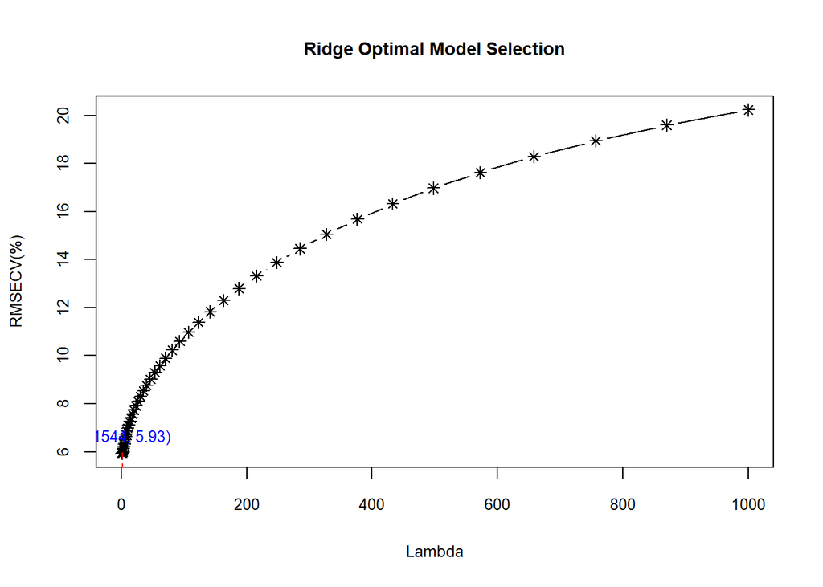

```r
# Extract results and best lambda
ridge_data <- fit_ridge_snv_sg_2d$results
best_lambda <- fit_ridge_snv_sg_2d$bestTune$lambda
y_RMSE <- ridge_data$RMSE[ridge_data$lambda == best_lambda]

# Plot RMSE against lambda
plot(
  ridge_data$lambda, ridge_data$RMSE, type = "b", col = "black", pch = 8, cex.axis = 0.8,
  xlab = "Lambda", ylab = "RMSECV(%)", cex.lab = 0.9,
  main = "Ridge Optimal Model Selection", cex.main = 0.9, cex.lab = 0.8
)

# Add line from x-axis to the specific point (optimal lambda)
segments(x0 = best_lambda, y0 = 0, x1 = best_lambda, y1 = y_RMSE, col = "red", lty = 2)

# Add line from y-axis to the specific point (corresponding RMSE)
segments(x0 = 0, y0 = y_RMSE, x1 = best_lambda, y1 = y_RMSE, col = "red", lty = 2)

# Add annotation for the optimal point
text(best_lambda, y_RMSE, labels = paste0("(", round(best_lambda, 4), ", ", round(y_RMSE, 2), ")"),
     pos = 3, col = "blue", cex = 0.8)
```